# 2019202265-贾耀博-第七八周作业

# 问题1

## 1.1

**试给出p分位数的Bootstrap置信区间求解程序，并对例1.2的数据汇总求解0.75和0.25分位数的置信区间**

```r
# 读入数据
nerve<-read.table("/Users/jiayaobo/PycharmProjects/nonparams/homework6/nerve.txt", fill = TRUE)
nerve<-as.matrix(nerve)
nerve<-as.vector(nerve)
nerve<-na.omit(nerve)
```

```r
# 求解p分位数的Bootstrap
n<-20
B<-1000
nerve.25 <- quantile(nerve, 0.25)
nerve.75 <- quantile(nerve, 0.75)
SD.nerve.25<-NULL
SD.nerve.75<-NULL
TBoot.25<-NULL
TBoot.75<-NULL
for (i in 1:B){
  Xsample <- sample(nerve, n, T)
  Tboot.25<-quantile(Xsample, 0.25)
  Tboot.75<-quantile(Xsample, 0.75)
  TBoot.25<-c(TBoot.25, Tboot.25)
  TBoot.75<-c(TBoot.75, Tboot.75)
  SD.nerve.25<-c(SD.nerve.25, sd(TBoot.25))
  SD.nerve.75<-c(SD.nerve.75, sd(TBoot.75))
}

Sd.25<-sd(TBoot.25)
Sd.75<-sd(TBoot.75)
```

```r
alpha<-0.05
z<-abs(qnorm(alpha/2))

#使用正态近似求解置信区间
ci.25.lower<-nerve.25-z*Sd.25
ci.25.upper<-nerve.25+z*Sd.25

ci.75.lower<-nerve.75-z*Sd.75
ci.75.upper<-nerve.75+z*Sd.75

print(paste0("0.95 CI of 0.25 percentile: ", "[",ci.25.lower," ,",ci.25.upper,"]" ))
```

```
## [1] "0.95 CI of 0.25 percentile: [0.0177629432636199 ,0.12223705673638]"
```

```r
print(paste0("0.95 CI of 0.75 percentile: ", "[",ci.75.lower," ,",ci.75.upper,"]" ))
```

```
## [1] "0.95 CI of 0.75 percentile: [0.132624601653933 ,0.467375398346067]"
```

## 1.2

**以下给出的是申请进入法学院学习的学生LSAT测试成绩和GPA成绩**

1. 计算$Y_i$和$Z_i$的相关系数

```r
lsat<-c(576,635,558,578,666,580,555,661,651,605,653,575,545,572,594)
gpa<-c(3.39,3.30,2.81,3.03,3.44,3.07,3.00,3.43,3.36,3.13,3.12,2.74,2.76,2.88,3.96)


print(paste0("Coefficient of lsat and gpq is：",cor(lsat, gpa)))
```

```
## [1] "Coefficient of lsat and gpq is：0.545918916179588"
```

2. 使用Bootstrap方法估计相关系数的标准误差

```r
dt<-data.frame(lsat=lsat, gpa=gpa)
n<-8
B<-1000
TBoot.cor<-NULL
SD.cor<-NULL
for(i in 1:B){
  Xsample<-sample(dt, n, T)
  Tboot.cor<-cor(Xsample)
  TBoot.cor<-c(TBoot.cor, Tboot.cor)
  SD.cor<-c(SD.cor, sd(TBoot.cor))
}
print(paste0("Bootstrap SD. is: ",sd(TBoot.cor)))
```

```
## [1] "Bootstrap SD. is: 0.225232843254149"
```

3. 计算置信度为0.95的相关系数Bootstrap枢轴量置信区间

```r
dt_cor<-cor(lsat, gpa)
Lc1<-2*dt_cor-quantile(TBoot.cor, 0.975)
Uc1<-2*dt_cor-quantile(TBoot.cor, 0.025)
print(paste0("CI of Correlative ratio: ", "[",Lc1," ,",Uc1,"]" ))
```

```
## [1] "CI of Correlative ratio: [0.0918378323591769 ,0.545918916179588]"
```

## 1.3

**构造一个模拟比较4个bootstrap置信区间的方法，$n=50$，$T(F)=\int (x-\mu)^3dF(x)/\sigma^3$是偏度。从分布$N(0,1)$中抽取出样本$Y_1,Y_2,\cdots,Y_n$,令$X_i=e^{Y_i},i=1,2,\cdots,n$。根据样本$X_1,X_2,\cdots,X_n$构造$T(F)$的4种类型的置信度为0.95的Bootstrap置信区间。多次重复上述步骤，估计4种区间的真实覆盖率**

```r
library(psych)

# 抽取样本
Y<-rnorm(1000, 0,1)
X<-exp(Y)

# 真实偏度
true.skew<-(exp(1)+2)*sqrt(exp(1)-1)
```

```r
n<-50
B<-1000

# 样本偏度
F.skew<-skew(X)

TBoot.skew<-NULL

for (i in 1:B){
  Xsample<-sample(X, n, T)
  Tboot.skew<-skew(Xsample)
  TBoot.skew<-c(TBoot.skew, Tboot.skew)
}
Sd.skew<-sd(TBoot.skew)
```

```r
alpha<-0.05

# 顺序统计量置信区间
loc<-NULL
l<-length(X)
conf <- pbinom(l,l,0.5)-pbinom(0,l,0.5)
for (k in 1:l){
  conf<- pbinom(l-k,l,0.5)-pbinom(k,l,0.5)
  if(conf<1-alpha){
    loc<-k-1
    break
  }
}

Lc1 <- sort(X)[loc]
Uc1<-sort(X)[l-k+1]
ORDER.interval <- c(Lc1, Uc1)
print(paste0("ORDER CI : ", "[",Lc1," ,",Uc1,"]" ))
```

```
## [1] "ORDER CI : [0.895527796948702 ,1.06662407844749]"
```

```r
# 正态置信区间

Lc1<-F.skew+qnorm(alpha/2)*Sd.skew
Uc1<-F.skew-qnorm(alpha/2)*Sd.skew
NORM.interval <- c(Lc1, Uc1)
print(paste0("Norm CI : ", "[",Lc1," ,",Uc1,"]" ))
```

```
## [1] "Norm CI : [2.41436644391146 ,6.80532715056256]"
```

```r
# 枢轴量置信区间
Lc1<-2*F.skew-quantile(TBoot.skew,0.975)
Uc1<-2*F.skew-quantile(TBoot.skew,0.025)
PIVOT.interval <- c(Lc1, Uc1)
print(paste0("Pivot CI : ", "[",Lc1," ,",Uc1,"]" ))
```

```
## [1] "Pivot CI : [4.03713079594655 ,8.21317077883857]"
```

```r
# 分位数置信区间

Lc1<-2*F.skew-quantile(TBoot.skew,0.025)
Uc1<-2*F.skew+quantile(TBoot.skew,0.975)
QUANTILE.interval <- c(Lc1, Uc1)
print(paste0("Quantile CI : ", "[",Lc1," ,",Uc1,"]" ))
```

```
## [1] "Quantile CI : [8.21317077883857 ,14.4022563930015]"
```

```r
# 上述过程重复1000次,适当减小B
B<-100
N<-1000
norm_bootstrap <- 0
pivot_bootstrap <- 0
quantile_bootstrap <- 0
order_bootstrap <- 0
for (i in 1:N){
  Y<-rnorm(1000, 0,1)
  X<-exp(Y)
  F.skew<-skew(X)
  TBoot.skew<-NULL
  for (j in 1:B){
    Xsample<-sample(X,n,T)
    Tboot.skew<-skew(Xsample)
    TBoot.skew<-c(TBoot.skew, Tboot.skew)
  }
  Sd.skew<-sd(TBoot.skew)
  # 正态
  Lc1<-F.skew+qnorm(0.025)*Sd.skew
  Uc1<-F.skew-qnorm(0.025)*Sd.skew
  if(true.skew>Lc1 && true.skew<Uc1){
    norm_bootstrap <- norm_bootstrap+1
  }
  # 枢轴量
  Lc1<-2*F.skew-quantile(TBoot.skew,0.975)
  Uc1<-2*F.skew-quantile(TBoot.skew,0.025)
  if(true.skew>Lc1 && true.skew<Uc1){
    pivot_bootstrap <- pivot_bootstrap+1
  }

  #分位数
  Lc1<-2*F.skew-quantile(TBoot.skew,0.025)
  Uc1<-2*F.skew+quantile(TBoot.skew,0.975)
  if(true.skew>Lc1 && true.skew<Uc1){
    quantile_bootstrap<-quantile_bootstrap+1
  }

  # 顺序统计量
  loc<-NULL
  l<-length(TBoot.skew)
  conf <- pbinom(l,l,0.5)-pbinom(0,l,0.5)
  for (k in 1:l){
    conf<- pbinom(l-k,l,0.5)-pbinom(k,l,0.5)
    if(conf<1-alpha){
      loc<-k-1
      break
    }
  }
  Lc1 <- sort(TBoot.skew)[loc]
  Uc1<-sort(TBoot.skew)[l-k+1]
  if(true.skew>Lc1 && true.skew<Uc1){
    order_bootstrap<-order_bootstrap+1
  }
}

print(paste0("Norm CI overlapping rate: ", norm_bootstrap/N))
```

```
## [1] "Norm CI overlapping rate: 0.501"
```

```r
print(paste0("Pivot CI overlapping rate: ", pivot_bootstrap/N))
```

```
## [1] "Pivot CI overlapping rate: 0.558"
```

```r
print(paste0("Quantile CI overlapping rate: ", quantile_bootstrap/N))
```

```
## [1] "Quantile CI overlapping rate: 0.26"
```

```r
print(paste0("Order CI overlapping rate: ", order_bootstrap/N))
```

```
## [1] "Order CI overlapping rate: 0"
```

## 1.4

**令$X_1,X_2,\cdots,X_n \sim N(\mu ,1)$.估计$\hat{\theta} = e^{\bar{X}}$ 是参数 $\theta=e^{\mu}$ 的MLE。用 $\mu=5$ 生成100个观测数据集**

1. 用枢轴量方法获得$\theta$的0.95置信区间和标准差。用参数Bootstrap方法获得$\theta$的0.95置信区间和估计标准差。用非参数Bootstrap方法获得$\theta$的0.95置信区间和估计标准差

```r
X<-rnorm(100, mean = 5, sd = 1)
Theta<-exp(mean(X))

n <- 20
B <- 1000

# 参数Bootstrap

TBoot.theta.par<-NULL

for ( i in 1:B){
  Xsample <- rnorm(n, mean=mean(X), sd=1)
  Tboot.theta<-exp(mean(Xsample))
  TBoot.theta.par<-c(TBoot.theta.par, Tboot.theta)
}

Lc1.par<-2*Theta-quantile(TBoot.theta.par, 0.975)
Uc1.par<-2*Theta-quantile(TBoot.theta.par,0.025)

Sd.theta.par<-sd(TBoot.theta.par)

print(paste0("Parametric Bootstrap Pivot CI : ", "[",Lc1.par," ,",Uc1.par,"]" ))
```

```
## [1] "Parametric Bootstrap Pivot CI : [73.3737788011107 ,209.231374194513]"
```

```r
print(paste0("Parametric Bootstrap Sd. : ", Sd.theta.par))
```

```
## [1] "Parametric Bootstrap Sd. : 34.9003211312542"
```

```r
# 非参数Bootstrap

TBoot.theta.npar<-NULL

for ( i in 1:B){
  Xsample<-sample(X,n,T)
  Tboot.theta<-exp(mean(Xsample))
  TBoot.theta.npar<-c(TBoot.theta.npar, Tboot.theta)
}

Lc1.npar<-2*Theta-quantile(TBoot.theta.npar, 0.975)
Uc1.npar<-2*Theta-quantile(TBoot.theta.npar,0.025)

Sd.theta.npar<-sd(TBoot.theta.npar)

print(paste0("Nonparametric Bootstrap Pivot CI : ", "[",Lc1.npar," ,",Uc1.npar,"]" ))
```

```
## [1] "Nonparametric Bootstrap Pivot CI : [71.1781927843811 ,207.598856869002]"
```

```r
print(paste0("Nonparametric Bootstrap Sd. : ", Sd.theta.npar))
```

```
## [1] "Nonparametric Bootstrap Sd. : 34.420518848135"
```

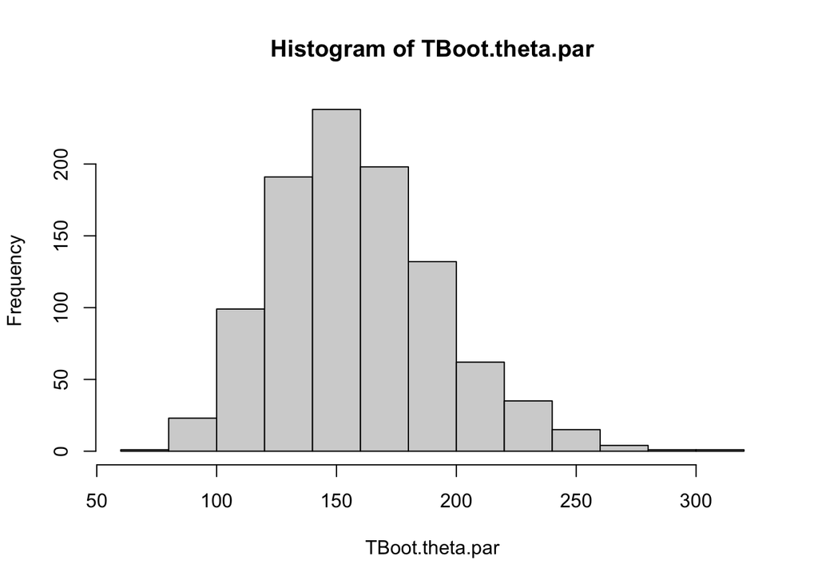

```r
hist(TBoot.theta.par)
```

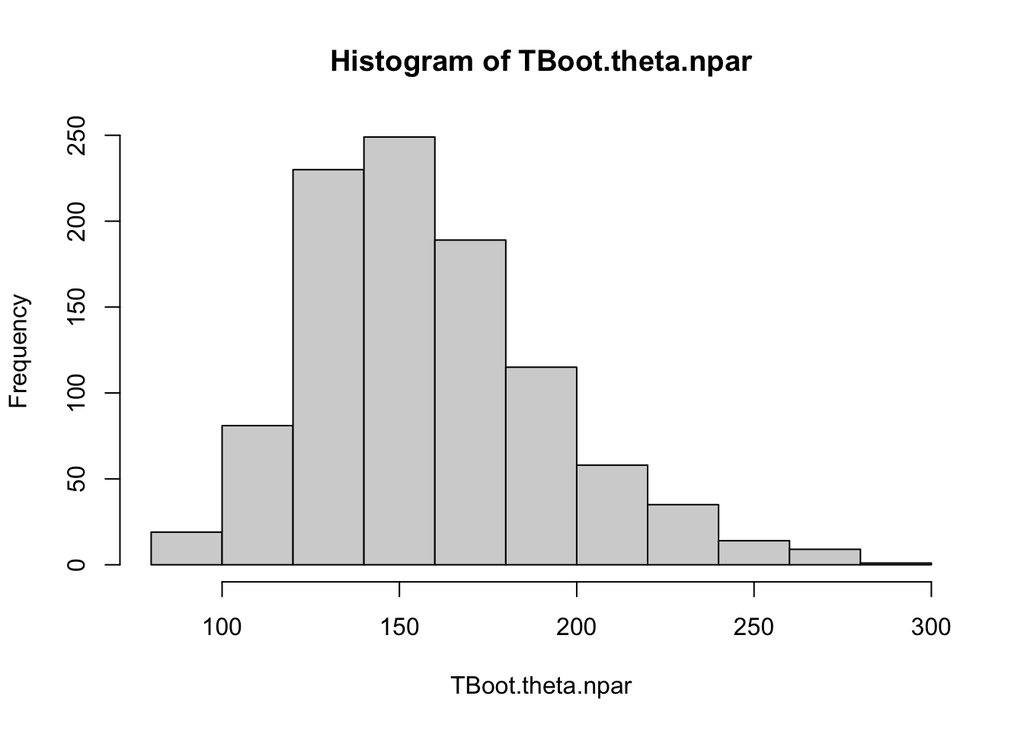

```r
hist(TBoot.theta.npar)
```

对比参数方法和非参数方法的估计直方图，可以看出参数法的分布要比非参数法得到的分布更加光滑，$\theta$呈现出对数正态分布

## 1.5

**为考察两种生产方式的生产效率是否有显著差异，随机抽取10人用方法A进行生产，抽取12人用方法B进行生产，并记录下22人的日产量。请问两种方法生产效率的影响不同吗？用wilcox.test应该怎样设置假设？得到怎样的结果？该问题可以用随机游程方法来解决吗？**

比较两种生产方式对生产效率的影响，使用wilcoxon检验应当做如下假设

$$H_0:A和B的生产效率分布的位置偏移为0 \leftrightarrow H_1: A和B的生产效率分布的位置偏移不为0$$

```r
A<-c(92,69,72,40,90,53,85,87,89,88)
B<-c(78,95,58,65,39,67,64,75,60,80,83,96)

wilcox.test(A,B)
```

```
##
##  Wilcoxon rank sum exact test
##
## data:  A and B
## W = 74, p-value = 0.381
## alternative hypothesis: true location shift is not equal to 0
```

通过wilcoxon检验，得到pvalue=0.381>0.05，从而不拒绝原假设,认为两种生产方法的效率无显著差别

下面进行随机游程检验，将所有数据混合后排序，并将A组数据标1，B组数据标0，这样如果两种生产效率相同，那么谁生产效率高是完全随机分布的

```r
sort(A)
```

```
##  [1] 40 53 69 72 85 87 88 89 90 92
```

```r
sort(B)
```

```
##  [1] 39 58 60 64 65 67 75 78 80 83 95 96
```

```r
library(tseries)
run<-c(0,1,1,0,0,0,0,0,1,1,0,0,0,0,1,1,1,1,1,1,0,0)
runs.test(as.factor(run))
```

```
##
##  Runs Test
##
## data:  as.factor(run)
## Standard Normal = -2.1637, p-value = 0.03049
## alternative hypothesis: two.sided
```

得到pvalue=0.03<0.05，从而拒绝原假设，认为两种生产方法生产效率有显著差异

## 1.6

**抑郁症发病率是否与季节有关？**

```r
# 进行卡方检验
dep<-c(495,503,491,581)
chisq.test(dep)
```

```
##
##  Chi-squared test for given probabilities
##
## data:  dep
## X-squared = 10.533, df = 3, p-value = 0.01454
```

根据卡方检验,pvalue=0.0145<0.05,从而拒绝原假设，认为抑郁症发病率与季节有关

## 1.6

**Suppose the cure rate for the standard treatment of a disease is 0.60.A new drug has been developed for the disease and it is thought that the curerate for patients using it will exceed 0.60. In a small clinical trial 48 patient shaving the disease were treated with the new drug and 34 were cured.**

1. Let p be the probability that a patient having the disease is cured by the new drug. Write the hypotheses of interest in terms of p

$$H_0:p=0.6 \leftrightarrow H_1:p\gt 0.6$$

2. Determine the p-value for the clinical study. What is the decision for a nominal level of 0.05 ?

```r
z.score <- (34/48-0.6)/sqrt(0.6*0.4/48)
1-pnorm(z.score)
```

```
## [1] 0.06275324
```

根据检验，得到pvalue=0.063>0.05,因此不能拒绝原假设

## 1.7

**Let p be the probability of success. Suppose it is of interest to test $H_0 : p = 0.30 \leftrightarrow H_A : p < 0.30$. Let S be the number of successes out of 75 trials. Suppose we reject $H_0$ , if $S \leq 16$**

1. Determine the significance level of the test.

```r
z.score<-(16/75-0.3)/sqrt(0.3*0.7/75)
print(paste0("Significance level is : ",pnorm(z.score)))
```

```
## [1] "Significance level is : 0.0507269063071039"
```

2. Determine the power of the test if the true p is 0.25

```r
pow.test<-pnorm(z.score+0.05/sqrt(0.3*0.7/75))
print(paste0("The power of the test is: ", pow.test))
```

```
## [1] "The power of the test is: 0.244175213592241"
```

3. Determine the power function for the test for the sequence for the probabilities of success in the set ${0.02,0.03,\cdots,0.35}$. Then obtain a plot of the power curve.

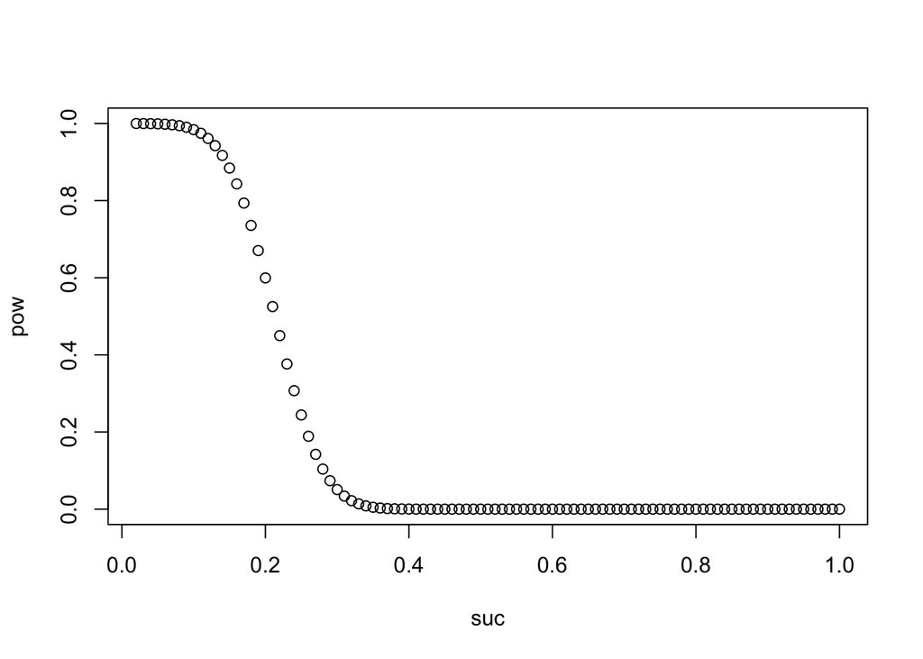

```r
suc<-seq(0.02:0.35,by=0.01)

# power function
pow<-pnorm(z.score+(0.3-suc)/sqrt(0.3*0.7/75))
plot(suc, pow)
```

# 问题2

## 2.1

**在一项研究毒品对人体攻击性影响的实验中，组A使用安慰剂，组B使用毒品。实验后进行攻击性测试，测量得分如下**

1. 请给出这个实验的原假设

考虑来自A组的样本独立同分布于$F_1(x)$,B组的样本独立同分布于$F(y-\mu)$,原假设可以表述为

$H_0:\mu=0$

2. 画出表现这些数据特点的曲线图

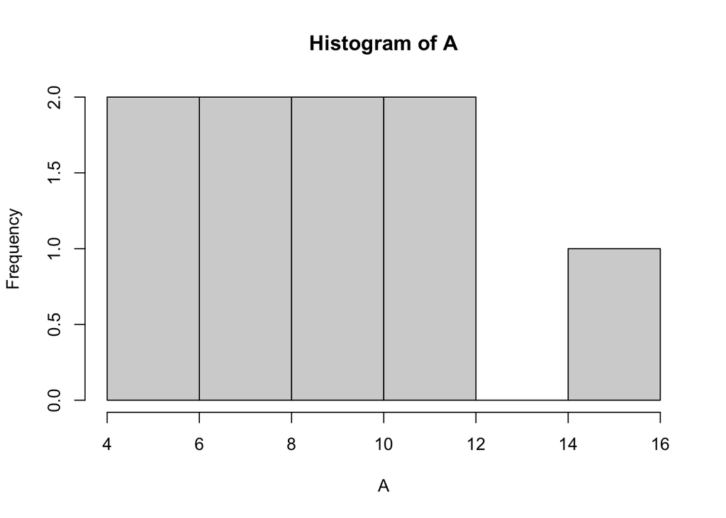

```r
A<-c(10,8,12,16,5,9,7,11,6)
B<-c(12,15,20,18,13,14,9,16)

# 画出两组数据的直方图和箱线图
hist(A)
```

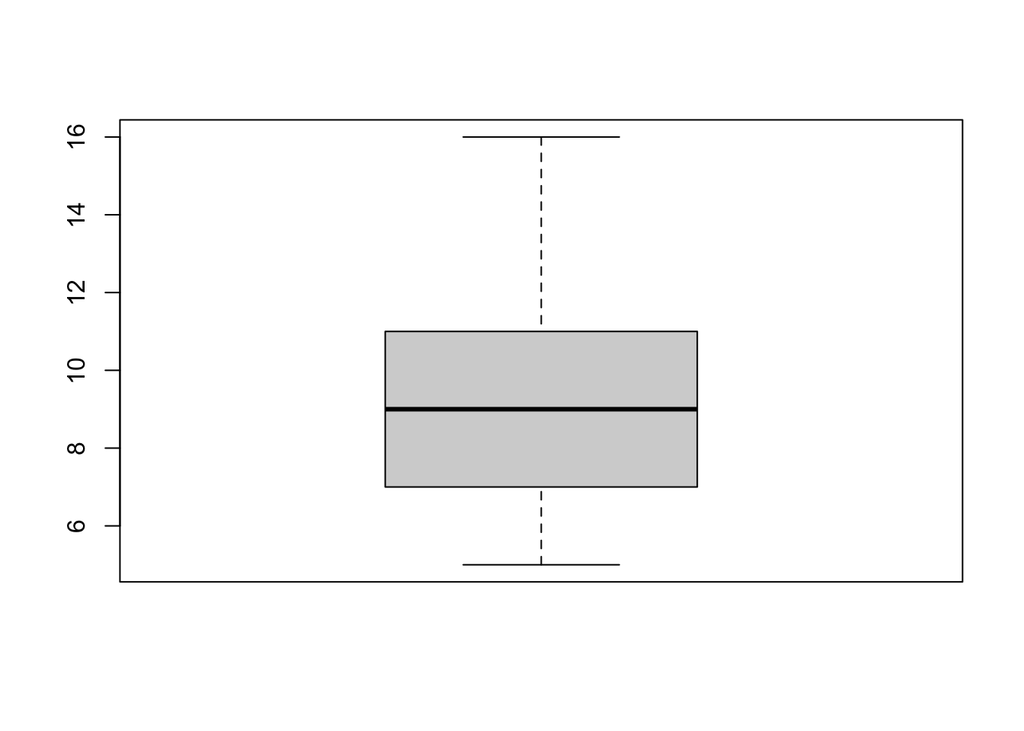

```r
boxplot(A)
```

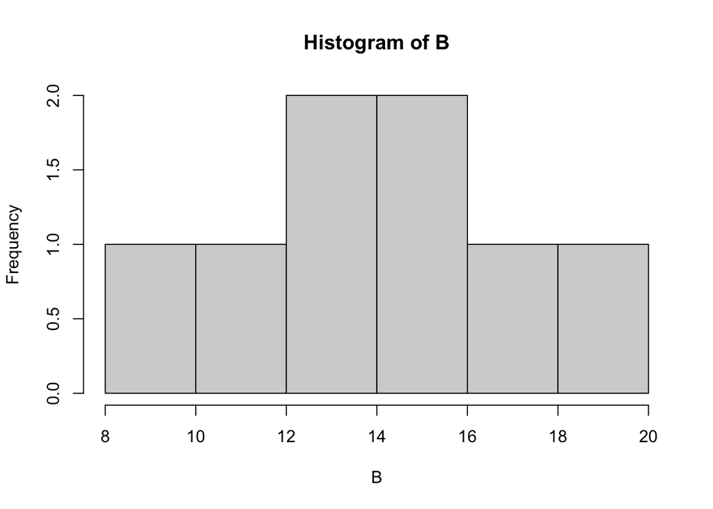

```r
hist(B)
```

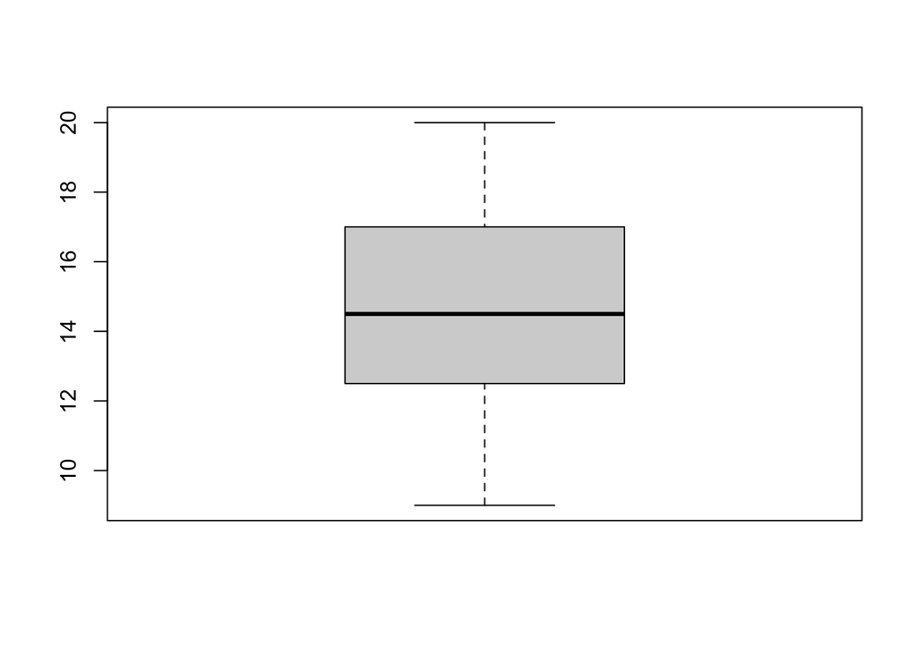

```r
boxplot(B)
```

3. 分析这些数据用哪种检验方法最合适

```r
# 计算两组数据方差和中位数的距离
abs(var(A)-var(B))
```

```
## [1] 0.4821429
```

```r
abs(median(A)-median(B))
```

```
## [1] 5.5
```

从方差角度来看，A，B两组方差基本相同而中位数相差较大，可以假定两组数据的分布存在一个位置漂移，因而可以采用Brown-Mood检验或者Wilcoxon-Mann-Whiteney秩和检验，而后者可以利用样本更多信息，并且无对称假定，因而采取Wilcoxon-Mann-Whiteney秩和检验

4. 用你选择的检验对数据进行分析

```r
wilcox.test(A,B)
```

```
##
##  Wilcoxon rank sum test with continuity correction
##
## data:  A and B
## W = 9.5, p-value = 0.01219
## alternative hypothesis: true location shift is not equal to 0
```

5. 是否有足够的证据拒绝原假设？如何解释数据

检验得到pvalue=0.0122<0.05,因而可以拒绝原假设，认为$\mu \not= 0$, 换而言之认为二者的中位数有显著差异

## 2.2

**针对例3.1进行如下操作：**

1. 给出0.25分位数的检验内容

$$H_0 : A组的0.25分位数=B组的0.25分位数$$

```r
BM.test<-function(x,y,alt,p=0.5){
  xy <- c(x,y)
  per.xy<-quantile(xy, p)
  t<- sum(xy>per.xy)
  lx<-length(x)
  ly<-length(y)
  lxy <- lx+ly
  A<- sum(x>per.xy)
  if(alt == "greater"){
    w<-1-phyper(A-1,lx,ly,t)
  }
  else if(alt == "less"){
    w<-phyper(A-1,lx,ly,t)
  }
  conting.table <- matrix(c(A,lx-A,lx,t-A,ly-(t-A),ly,t,lxy-t,lxy),3,3)
  col.name<-c("X","Y","XY")
  row.name<-c(">PXY", "<PXY", "TOTAL")
  dimnames(conting.table)<-list(row.name, col.name)
  list(contingency.table=conting.table, p.value = w)
}

BM.test(A,B,"less",0.25)
```

```
## $contingency.table
##       X Y XY
## >PXY  4 7 11
## <PXY  5 1  6
## TOTAL 9 8 17
##
## $p.value
## [1] 0.00678733
```

2. 应用(1)的结果分析两组数据的0.25分位数是否有差异，对结果进行合理解释

得到Brown-mood检验的pvalue=0.0068<0.01,从而拒绝原假设，认为A组和B组的0.25分位数有显著性差异

3. 给出0.75分位数的检验内容(包括原假设、过程、决策)

$$H_0 : A组的0.75分位数=B组的0.75分位数$$

```r
BM.test(A,B,alt = "less",0.75)
```

```
## $contingency.table
##       X Y XY
## >PXY  1 3  4
## <PXY  8 5 13
## TOTAL 9 8 17
##
## $p.value
## [1] 0.02941176
```

4. 应用(3)的结果分析两组数据的0.75分位数是否有差异，对结果进行合理解释

得到Brown-mood检验的pvalue=0.03<0.05,从而拒绝原假设，认为A组和B组的0.75分位数有显著性差异

## 2.3

**从最近雇佣的职员中随机选出22人，一般接受人际关系方面的课程训练，剩下11人组成控制组。在训练之后，22个人都在一个与顾客的模拟会面中被观察，观察者以20分制对他们的表现进行评级，得分越高，评级越高**

1. 这项研究的原假设和备择假设各是什么？

$$H_0: 两组得分分布的位置漂移为0\leftrightarrow H_1: 两组得分分布的位置漂移不为0$$

2. 画出这些表示数据特点的曲线图

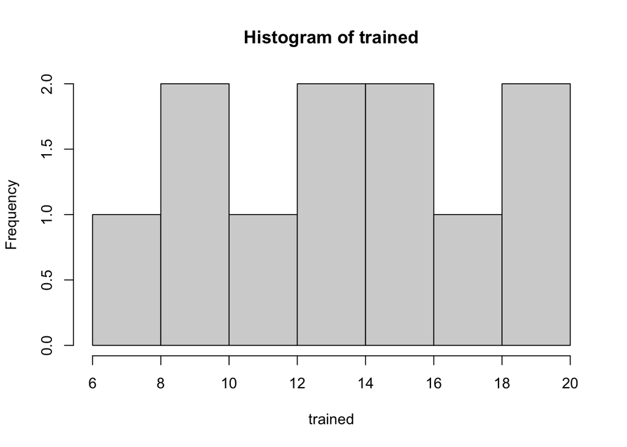

```r
trained<-c(18,15,9,10,14,16,11,13,19,20,6)
ctrl<-c(12,13,9,8,1,2,7,5,3,2,4)

# 画出直方图和箱线图
hist(trained)
```

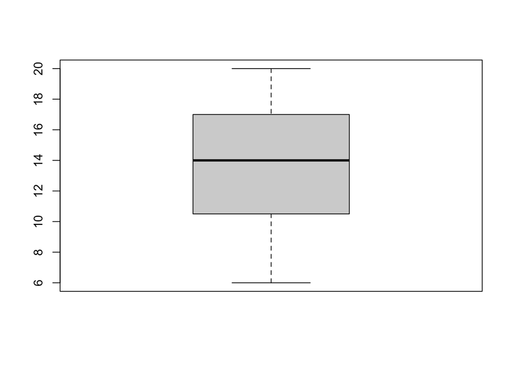

```r
boxplot(trained)
```

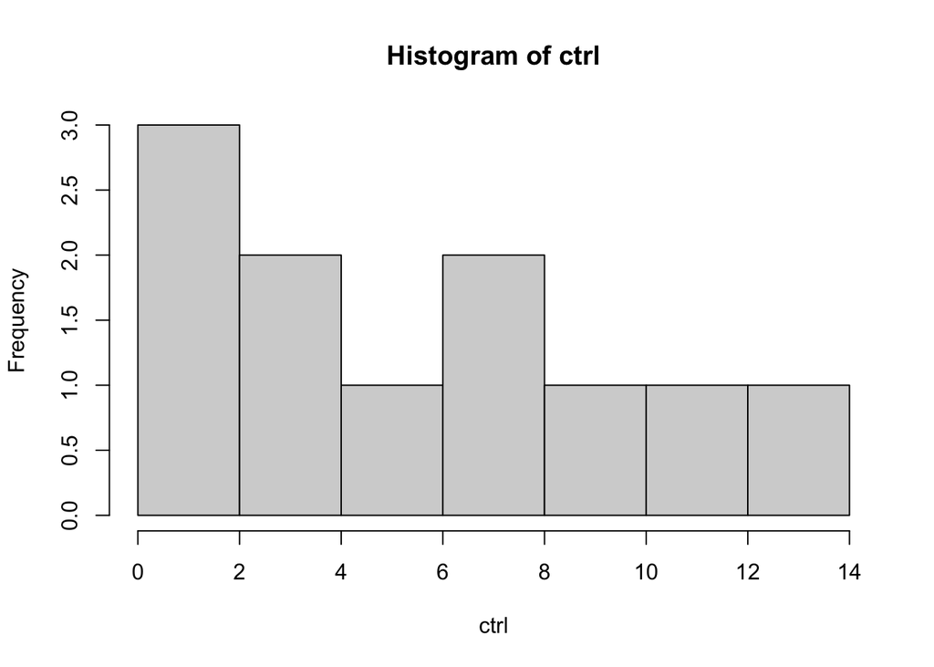

```r
hist(ctrl)
```

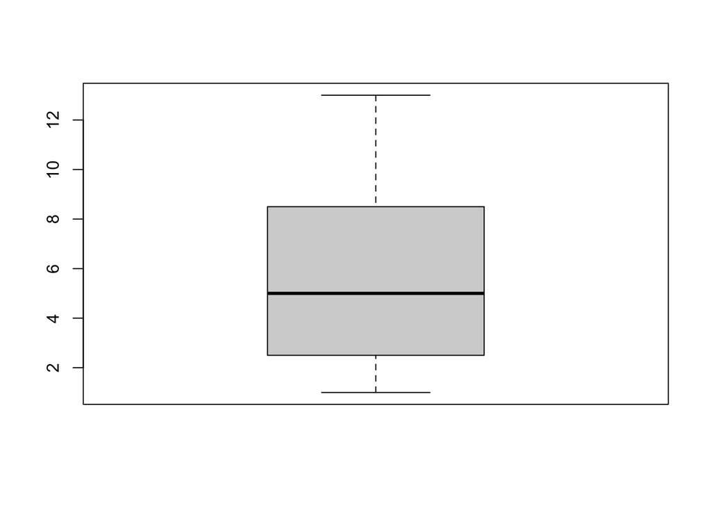

```r
boxplot(ctrl)
```

3. 你认为分析这些数据用哪种检验方法最合适？

```r
abs(var(ctrl)-var(trained))
```

```
## [1] 2.618182
```

```r
abs(median(ctrl)-median(trained))
```

```
## [1] 9
```

我认为采用Wilcoxon-Mann-Whiteney秩和检验进行分析比较合理，两组数据方差差距不大，而中位数相差很大，因而可以认为他们的分布存在一个位置漂移，而且该检验可以利用样本更多信息，并且无对称假定，因而采取Wilcoxon-Mann-Whiteney秩和检验

4. 用你的检验方法对这些数据进行分析

```r
wilcox.test(trained, ctrl)
```

```
##
##  Wilcoxon rank sum test with continuity correction
##
## data:  trained and ctrl
## W = 109, p-value = 0.001607
## alternative hypothesis: true location shift is not equal to 0
```

5. 是否有足够的证据拒绝原假设？如何解释数据？

根据检验结果，得到pvalue=0.0016<0.01,从而可以拒绝原假设，认为两组数据分布存在一个明显的不为零的位置漂移

# 3

## 3.1

**为考察学生的阅读理解能力，对10名学生训练前后的阅读能力测试结果如下。请设计置换实验，根据如下数据进行阅读训练前后阅读测试能力变化差值d的wilcoxon检验，请计算p值**

$$H_0:训练前后阅读能力无差异\leftrightarrow H_1: 训练后能提高阅读能力$$

```r
untrained<-c(61,69,68,62,74,95,89,68,71,59)
trained<-c(68,67,73,65,79,93,85,70,73,69)

d<-trained-untrained
dpm<-c(d,-d)

#每次抽取n个
n<-length(d)

#共进行B次
B<-500

dbs<-matrix(sample(dpm,n*B,replace = T), ncol = n)
wilcox.teststat<-function (x)wilcox.test(x)$statistic
bs.teststat<-apply(dbs,1,wilcox.teststat)
mean(bs.teststat>=wilcox.teststat(dpm))
```

```
## [1] 0
```

得到置换检验的pvalue=0，从而拒绝原假设，认为训练后对学生阅读能力有提升